# Lab 4 R Version

```r
library(dplyr)
library(tidyr)
library(ggplot2)
library(readxl)
library(ggthemes)
library(magrittr)
```

```r
IndustryTwo<-read_xlsx("Lab4_Files/MSDS6370_LAB04.xlsx")
```

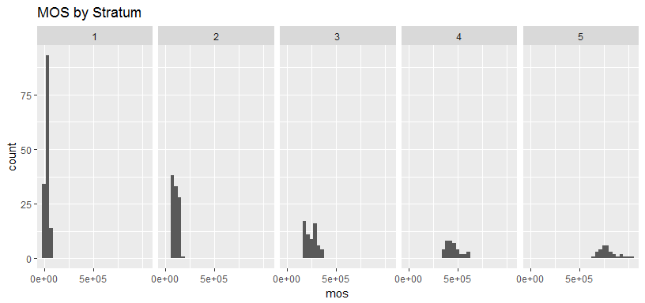

```r
IndustryTwo %>% ggplot(aes(x=mos)) + geom_histogram() + facet_wrap(~stratum, ncol=5) + scale_x_continuous(breaks=c(0, 500000)) + ggtitle("MOS by Stratum")
```

You may use SAS proc means or Excel to calculate the means, sums, and standard deviations required for the allocations in No. 1, 2, 3.

1. For a sample of size 50 from the population for Industry 2, use proportional allocation to determine the sample size for each of the 5 strata. Enter these in Table 1 on the Results page.

| stratum | count | share | FromThisStratum | Unrounded |
| --- | --- | --- | --- | --- |
| 1 | 141 | 0.37801609 | 19 | 18.900804 |
| 2 | 100 | 0.26809651 | 13 | 13.404826 |
| 3 | 63 | 0.16890080 | 8 | 8.445040 |
| 4 | 38 | 0.10187668 | 5 | 5.093834 |
| 5 | 31 | 0.08310992 | 4 | 4.155496 |

2. For a sample of size 50 from the population for Industry 2, determine the sample size for each of the 5 strata using Neyman allocation where the administrative measure of size of each unit is used in calculating standard deviation for each stratum. Enter these in Table 2 on the Results page

```r
sample_Size = 50
CountsByStrata <- IndustryTwo %>% group_by(stratum) %>% summarise(count=n(), Size = sd(mos)) %>% mutate(share=Size/sum(Size)) %>% mutate(FromThisStratum= round(sample_Size * share, 0), unrounded=sample_Size * share)
CountsByStrata
```

| stratum | count | Size | share | FromThisStratum | unrounded |
| --- | --- | --- | --- | --- | --- |
| 1 | 141 | 15484.93 | 0.05712313 | 3 | 2.856157 |
| 2 | 100 | 29062.08 | 0.10720855 | 5 | 5.360427 |
| 3 | 63 | 56464.72 | 0.20829549 | 10 | 10.414774 |
| 4 | 38 | 71915.33 | 0.26529201 | 13 | 13.264601 |
| 5 | 31 | 98152.82 | 0.36208082 | 18 | 18.104041 |

3. For a sample of size 50 from the population for Industry 2, determine the sample size for each of the 5 strata using the sum of the measure of size in stratum h in place of N_h σ_h in a Neyman allocation. Enter these in Table 3 on the Results page.

```r
sample_Size = 50
CountsByStrata <- IndustryTwo %>% group_by(stratum) %>% summarise(count=n(), Size = sum(mos)) %>% mutate(share=Size/sum(Size)) %>% mutate(weight=Size, FromThisStratum= round(sample_Size * share, 0), unrounded=sample_Size * share)
CountsByStrata
```

| stratum | count | Size | share | weight | FromThisStratum | unrounded |
| --- | --- | --- | --- | --- | --- | --- |
| 1 | 141 | 4599050 | 0.06317201 | 4599050 | 3 | 3.158601 |
| 2 | 100 | 10650570 | 0.14629499 | 10650570 | 7 | 7.314749 |
| 3 | 63 | 15590567 | 0.21415021 | 15590567 | 11 | 10.707510 |
| 4 | 38 | 17290210 | 0.23749630 | 17290210 | 12 | 11.874815 |
| 5 | 31 | 24671620 | 0.33888649 | 24671620 | 17 | 16.944324 |

1. Use SAS Procedure Surveyselect to select a sample of size 50 using the proportional allocation to strata as determined in No. 1 above. Output the selected units to a file named propsample.

```r
stratumName<-c(1, 2, 3, 4, 5)
selection<-c(19, 13, 8, 5, 5)

thisStratum <- 1

AllSamples<-data.frame()

for (thisStratum in stratumName) {
  Sampled <-  IndustryTwo %>% filter(stratum == thisStratum) %>% sample_n(selection[thisStratum], replace=FALSE) %>% group_by(stratum) %>% summarise(SampleMean = mean(Sales), SampleSD = sd(Sales))

  AllSamples <- rbind(AllSamples, Sampled)

}
```

```r
stratumName<-c(1, 2, 3, 4, 5)
selection<-c(4, 5, 10, 13, 18)

thisStratum <- 1

AllSamples<-data.frame()

for (thisStratum in stratumName) {
  Sampled <-  IndustryTwo %>% filter(stratum == thisStratum) %>% sample_n(selection[thisStratum], replace=FALSE) %>% group_by(stratum) %>% summarise(SampleMean = mean(Sales), SampleSD = sd(Sales))

  AllSamples <- rbind(AllSamples, Sampled)

}
```

```r
stratumName<-c(1, 2, 3, 4, 5)
selection<-c(3, 7, 11, 12, 17)
thisStratum <- 1
AllSamples<-data.frame()
for (thisStratum in stratumName) {
  Sampled <-  IndustryTwo %>% filter(stratum == thisStratum) %>% sample_n(selection[thisStratum], replace=FALSE) %>% group_by(stratum) %>% summarise(SampleMean = mean(Sales), SampleSD = sd(Sales))
  AllSamples <- rbind(AllSamples, Sampled)

}
```